# WPB Drought

Zjrobbin

6/12/2020

### Comparing_Drought_Drivers.RMD

This script calculates the Percipitation-Evapotranspirtion, Standard Precipitation Index, and Palmers Drought Severity Index drought drivers that could be used within the model for the four sites we modeled. It also compares those drivers to the mortality experienced by the trees for each year and calculates an R2.

```r
## This file takes the ET and PPT and creates a delta. At this point I am not sure which measure we are using by the defualt now
## is to take a five year mean for ET and PPT and calculate the cumuluative((ET-PPT)-mean(ET5-PPT5))
##Plotter
library(RColorBrewer)
library(rcarbon)
library(RcppRoll)
library(lubridate)
ff<-function(x){
  return(as.numeric(as.character(x)))
}
#display.brewer.all()
Pal_1<-brewer.pal(9,"Set3")
###REad ET
ET<-read.csv("C:/Users/zacha/Documents/GitHub/IMAP_Python_Project/WPB_Model/WPB_Inputs/WPB_ET_1_24.csv")
colnames(ET)[2]<-"Dates"
ET$Dates<-as.Date(ET$Dates,tryFormats = ("%Y-%m-%d"))


## Set a date list so we have continous dates
Dates_Sub=data.frame(Dates=seq(as.Date("2001-01-01"),as.Date("2018-12-31"),1))
Dates_Sub<-as.data.frame(Dates_Sub)
Dates_Sub$Month<-month(Dates_Sub$Dates)
Dates_Sub$Day<-day(Dates_Sub$Date)
Dates_Sub$Year<-year(Dates_Sub$Dates)
DatesNoLeap<-Dates_Sub[!(Dates_Sub$Month == 2 & Dates_Sub$Day == 29),]



#### Spread ET on continous.
Continous<-merge(DatesNoLeap,ET,by="Dates",all.x=TRUE)
Continous<-Continous[,c(-2,-3,-4)]
Continous$Low_LowElShape_Out<-ff(Continous$Low_LowElShape_Out)
Continous$Low_MedElShape_Out<-ff(Continous$Low_MedElShape_Out)
Continous$Low_HighElShape_Out<-ff(Continous$Low_HighElShape_Out)
Continous$High_LowElShape_Out<-ff(Continous$High_LowElShape_Out)
Continous$High_MedElShape_Out<-ff(Continous$High_MedElShape_Out)
Continous$High_HighElShape_Out<-ff(Continous$High_HighElShape_Out)
Continous[is.na(Continous)]<-0.0
Continous<-Continous[,-2]
#boxplot(Continous[-1])




Dates=data.frame(Dates=seq(as.Date("2001-01-01"),as.Date("2018-01-01"),1))
# This is a function to smooth the 8 day measurement across the 8 days
RunET<-runMean(ET,n=8)

PPT_in<-read.csv("C:/Users/zacha/Documents/GitHub/IMAP_Python_Project/WPB_Model/WPB_Inputs/WPB_Prcp_1_14.csv")
colnames(PPT_in)<-c(paste0(colnames(PPT_in),"PRCP"))
colnames(PPT_in)[2]<-"Dates"
PPT_in<-PPT_in[-1]
PPT_in$Dates<-as.Date(PPT_in$Dates)

Dates<-as.Date(seq(
  from=as.POSIXct("1997-01-01 0:00", tz="UTC"),
  to=as.POSIXct("2018-01-01 0:00", tz="UTC"),
  by="day"
) )



PPT_sub<-PPT_in[PPT_in$Dates %in% as.Date(Dates),]
### Merge the dates
Delta_df<-merge(Continous,PPT_sub,by="Dates",all.x=TRUE)

### Look at the difference between ppt and et for each day.
Delta_df$Low_LowElDelta<-Delta_df$Low_LowElShape_OutPRCP-Delta_df$Low_LowElShape_Out
Delta_df$Low_LowElDelta[is.na(Delta_df$Low_LowElDelta)]<-0
#Delta_df$Low_LowElDelta[is.na(Delta_df$Low_LowElDelta)]
Delta_df$Low_MedElDelta<-Delta_df$Low_MedElShape_OutPRCP-Delta_df$Low_MedElShape_Out
Delta_df$Low_MedElDelta[is.na(Delta_df$Low_MedElDelta)]<-0
Delta_df$Low_HighElDelta<-Delta_df$Low_HighElShape_OutPRCP-Delta_df$Low_HighElShape_Out
Delta_df$Low_HighElDelta[is.na(Delta_df$Low_HighElDelta)]<-0
Delta_df$High_LowElDelta<-Delta_df$High_LowElShape_OutPRCP-Delta_df$High_LowElShape_Out
Delta_df$High_LowElDelta[is.na(Delta_df$High_LowElDelta)]<-0
Delta_df$High_MedElDelta<-Delta_df$High_MedElShape_OutPRCP-Delta_df$High_MedElShape_Out
Delta_df$High_MedElDelta[is.na(Delta_df$High_MedElDelta)]<-0
Delta_df$High_HighElDelta<-Delta_df$High_HighElShape_OutPRCP-Delta_df$High_HighElShape_Out
Delta_df$High_HighElDelta[is.na(Delta_df$High_HighElDelta)]<-0

Dates_2<-as.Date(seq(
  from=as.POSIXct("2001-01-01 0:00", tz="UTC"),
  to=as.POSIXct("2018-01-01 0:00", tz="UTC"),
  by="day"
) )

Delta_df_sub<-Delta_df[Delta_df$Dates %in% Dates_2,]
Deltas<-Delta_df_sub[,c(14:19)]


Mortality<-read.csv("C:/Users/zacha/Documents/GitHub/IMAP_Python_Project/WPB_Model/WPB_Inputs/WPBPercentMortality.csv")
Mortality<-Mortality[,-1]
Mortality<-Mortality[-17,]
colnames(Mortality)<-c("Year","AllPerc","SmallPerc","LargePerc")
Mortality$Dates<-seq(as.Date("2003-07-02"),as.Date("2018-07-02"),by="year")
Mortality<-Mortality[Mortality$Year %in% seq(2008,2017),]
```

```r
Mortality2<-read.csv("C:/Users/zacha/Documents/GitHub/IMAP_Python_Project/WPB_Model/WPB_Inputs/WPB_Trees_6_20.csv")

MortalityStack<-Mortality2[5:17]+Mortality2[18:30]
MortalityStack<-cbind((Mortality2[3]+Mortality2[4]),MortalityStack)
MortalityStack<-as.data.frame(t(MortalityStack))
colnames(MortalityStack)<-c("HE_LL_m","LE_LL_m","HE_HL_m","LE_HL_m")
MortalityStack$Year<-seq(2005,2018)
dfPerc<-NULL
for(i in 2: length(MortalityStack$Year)){

  rowPerc<-(MortalityStack[i-1,1:4]-MortalityStack[i,1:4])/MortalityStack[i-1,1:4]
  rowPerc<-cbind(MortalityStack$Year[i],rowPerc)
  dfPerc<-rbind(rowPerc,dfPerc)
}

colnames(dfPerc)[1]<-"Year"
dfPerc<-dfPerc[order(dfPerc[,1]),]
```

### Calculating R2 for P-ET

```r
Merged<-merge(Delta_df,Mortality,all.x=T,by="Dates")
Merged<-Merged[Merged$Dates>as.Date("2001-01-01"),]
library(lubridate)
Merged$LL[1460:6569]<-roll_sum(Merged$Low_LowElDelta-mean(Merged$Low_LowElDelta),1460)
Merged$LM[1460:6569]<-roll_sum(Merged$Low_MedElDelta-mean(Merged$Low_MedElDelta),1460)
Merged$HM[1460:6569]<-roll_sum(Merged$High_LowElDelta-mean(Merged$High_LowElDelta),1460)
Merged$HH[1460:6569]<-roll_sum(Merged$High_HighElDelta-mean(Merged$High_HighElDelta),1460)





byyear <- aggregate(cbind(LL, LM,HM,HH)~year(as.Date(Dates)),
                    data=Merged,FUN=mean)

#colnames(Delta_df_sub)
colnames(byyear)[1]<-c("Year")
Merged_byyear<-merge(byyear,Mortality,all.x=T,by="Year")

head(Merged_byyear)
```

```
##   Year          LL          LM         HM         HH     AllPerc   SmallPerc
## 1 2005    6.963055   90.501447   41.61021   11.16695          NA          NA
## 2 2006  240.520449  415.249419  568.45078  641.57713          NA          NA
## 3 2007  101.407791  258.052075  449.35850  491.03169          NA          NA
## 4 2008  142.711699  293.511949  340.29149  371.28410 0.007766252 0.008944167
## 5 2009  -98.588576   -9.903083   30.06637   98.47927 0.001947366 0.000000000
## 6 2010 -169.692590 -120.498854 -410.45266 -400.19274 0.012567380 0.017729755
##     LargePerc      Dates
## 1          NA       <NA>
## 2          NA       <NA>
## 3          NA       <NA>
## 4 0.005560829 2008-07-02
## 5 0.005560829 2009-07-02
## 6 0.002788167 2010-07-02
```

```r
Merged_byyear$mean<-rowMeans(Merged_byyear[2:5])

summary(lm(Merged_byyear$AllPerc[5:15]~Merged_byyear$mean[5:15]))
```

```
##
## Call:
## lm(formula = Merged_byyear$AllPerc[5:15] ~ Merged_byyear$mean[5:15])
##
## Residuals:
##       Min        1Q    Median        3Q       Max
## -0.079975 -0.033639  0.005581  0.031442  0.097839
##
## Coefficients:
##                            Estimate Std. Error t value Pr(>|t|)
## (Intercept)               3.622e-02  2.147e-02   1.687   0.1355
## Merged_byyear$mean[5:15] -1.274e-04  4.702e-05  -2.710   0.0302 *
## ---
## Signif. codes:  0 '***' 0.001 '**' 0.01 '*' 0.05 '.' 0.1 ' ' 1
##
## Residual standard error: 0.06079 on 7 degrees of freedom
##   (2 observations deleted due to missingness)
## Multiple R-squared:  0.512,  Adjusted R-squared:  0.4423
## F-statistic: 7.344 on 1 and 7 DF,  p-value: 0.0302
```

```r
byyear2<-byyear[2:14,]
Oneclim<-c(byyear2$LM,byyear2$LL,byyear2$HH,byyear2$HM)
OneMortality<-c(dfPerc$HE_LL_m,dfPerc$LE_LL_m,dfPerc$HE_HL_m,dfPerc$LE_HL_m)
summary(lm(Oneclim~OneMortality))
```

```
##
## Call:
## lm(formula = Oneclim ~ OneMortality)
##
## Residuals:
##     Min      1Q  Median      3Q     Max
## -968.91 -216.98   65.17  238.18  664.75
##
## Coefficients:
##              Estimate Std. Error t value Pr(>|t|)
## (Intercept)    115.35      54.44   2.119   0.0391 *
## OneMortality -2438.52     461.30  -5.286 2.75e-06 ***
## ---
## Signif. codes:  0 '***' 0.001 '**' 0.01 '*' 0.05 '.' 0.1 ' ' 1
##
## Residual standard error: 363.4 on 50 degrees of freedom
## Multiple R-squared:  0.3585, Adjusted R-squared:  0.3457
## F-statistic: 27.94 on 1 and 50 DF,  p-value: 2.748e-06
```

```r
print(byyear2$LM)
```

```
##  [1]  415.249419  258.052075  293.511949   -9.903083 -120.498854  421.987021
##  [7]  274.105888  123.966242 -339.006135 -948.940454 -722.211587  157.850270
## [13]  174.295391
```

```r
#print(dfPerc$HE_LL_m)
```

```r
#library(dplyr)
# library(zoo)
# M4<-merge(Dates,m3,by="Dates",all.x=T)
#
# #### Linear interpolation
# Interpol<-data.frame(Dates=seq(M4$Dates[1],M4$Dates[nrow(M4)],by=1))%>%
#   full_join(M4,by="Dates")%>%
#   mutate(HE_HL=na.approx(HE_HL_pal),HE_LL=na.approx(HE_LL_pal),
#          LE_HL=na.approx(LE_HL_pal),LE_LL=na.approx(LE_LL_pal))
# Interpol<-Interpol[,c(-2,-3,-4,-5)]
```

```r
Delta_df_sub<-Delta_df[Delta_df$Dates %in% Dates_2,]
Deltas<-Delta_df_sub[,c(14:19)]
```

### Palmers Drought Severity Index

https://developers.google.com/earth-engine/datasets/catalog/IDAHO_EPSCOR_PDSI

This is from the same group that produced MACA they have Palmers drought severity index going back ot 1979 on a thrice monthly timestep (1,10,20th) From the description

"The Palmer Drought Severity Index dataset provides high spatial resolution (~4-km) thrice-monthly estimates of this widely used measure of integrated water supply and demand anomalies across the contiguous United States from 1979-present. The PDSI is calculated using precipitation and potential evapotranspiration derived from the gridded meteorological dataset of Abatzoglou (2013).

Potential evapotranspiration is computed using the Penman-Montieth equation for a reference grass surface. Available soil water holding capacity in the top 2.5m of the soil was derived from the STATSGO soils database and used in the computations. Whereas PDSI has typically been computed on monthly timescales, we compute these data three-times a month to provide more timely updates. Due to the spin-up of PDSI calculations, data for the first year of record should be used sparingly.

This dataset contains provisional products that are replaced with updated versions when the complete source data become available. Products can be distinguished by the value of the ‘status’ property. At first, assets are ingested with status=‘early’. After several days, they are replaced by assets with status=‘provisional’. After about 2 months, they are replaced by the final assets with status=‘permanent’."

I took the average bounded by the shape file for each of the WPB Locations

```r
HE_HL_pal<-read.csv("C:/Users/zacha/Desktop/WPB_Palmers/WPB_Palmers/HE_HL_WPB_Table.csv")
colnames(HE_HL_pal)<-c("Dates","HE_HL_pal")
HE_LL_pal<-read.csv("C:/Users/zacha/Desktop/WPB_Palmers/WPB_Palmers/HE_LL_WPB_Table.csv")
colnames(HE_LL_pal)<-c("Dates","HE_LL_pal")
LE_HL_pal<-read.csv("C:/Users/zacha/Desktop/WPB_Palmers/WPB_Palmers/LE_HL_WPB_Table.csv")
colnames(LE_HL_pal)<-c("Dates","LE_HL_pal")
LE_LL_pal<-read.csv("C:/Users/zacha/Desktop/WPB_Palmers/WPB_Palmers/LE_LL_WPB_Table.csv")
colnames(LE_LL_pal)<-c("Dates","LE_LL_pal")
m1<-merge(HE_HL_pal,HE_LL_pal,by="Dates",all.x=T)
m2<-merge(m1,LE_HL_pal,by="Dates",all.x=T)
m3<-merge(m2,LE_LL_pal,by="Dates",all.x=T)

Mortality<-read.csv("C:/Users/zacha/Documents/GitHub/IMAP_Python_Project/WPB_Model/WPB_Inputs/WPBPercentMortality.csv")
Mortality<-Mortality[,-1]
Mortality<-Mortality[-17,]
colnames(Mortality)<-c("Year","AllPerc","SmallPerc","LargePerc")
Mortality$Dates<-seq(as.Date("2003-07-10"),as.Date("2018-07-10"),by="year")
Mortality<-Mortality[Mortality$Year %in% seq(2008,2017),]

m3$Dates<-as.Date(m3$Dates)
m3<-m3[order(m3$Dates),]
Merged<-merge(m3,Mortality,all.x=T,by="Dates")
Merged<-Merged[Merged$Dates>"2003-01-01",]
Dates<-data.frame(Dates=seq(as.Date("2003-01-01"),as.Date("2018-01-01"),by="day"))
library(dplyr)
library(zoo)
M4<-merge(Dates,m3,by="Dates",all.x=T)

#### Linear interpolation
Interpol<-data.frame(Dates=seq(M4$Dates[1],M4$Dates[nrow(M4)],by=1))%>%
  full_join(M4,by="Dates")%>%
  mutate(HE_HL=na.approx(HE_HL_pal),HE_LL=na.approx(HE_LL_pal),
         LE_HL=na.approx(LE_HL_pal),LE_LL=na.approx(LE_LL_pal))
Interpol<-Interpol[,c(-2,-3,-4,-5)]
```

### Interpolated Palmers

```r
Interpol<-read.csv("C:/Users/zacha/Documents/GitHub/IMAP_Python_Project/WPB_Model/WPB_Inputs/WPB_Palmers.csv")
Interpol$Dates<-as.Date(Interpol$Dates,tryFormats = c("%m/%d/%Y"))
#?as.Date
Merged_PDSI<-merge(Interpol,Mortality,all.x=T,by="Dates")
Merged_PDSI<-Merged_PDSI[Merged_PDSI$Dates>as.Date("2005-01-01"),]
```

### Calculating the R2 for PDSI

```r
byyear <- aggregate(cbind(LE_LL, LE_HL,HE_LL,HE_HL)~year(as.Date(Dates)),
             data=Interpol,FUN=mean)
#head(byyear)
colnames(byyear)[1]<-c("Year")

Merged_byyear<-merge(byyear,Mortality,all.x=T,by="Year")
#head(Merged_byyear)
Merged_byyear$mean<-rowMeans(Merged_byyear[2:5])
#plot(Merged_byyear$mean)
summary(lm(Merged_byyear$AllPerc~Merged_byyear$mean))
```

```
##
## Call:
## lm(formula = Merged_byyear$AllPerc ~ Merged_byyear$mean)
##
## Residuals:
##       Min        1Q    Median        3Q       Max
## -0.067647 -0.035470 -0.014024  0.006785  0.177069
##
## Coefficients:
##                    Estimate Std. Error t value Pr(>|t|)
## (Intercept)         0.03394    0.02646   1.283    0.236
## Merged_byyear$mean -0.01458    0.01050  -1.388    0.202
##
## Residual standard error: 0.07448 on 8 degrees of freedom
##   (6 observations deleted due to missingness)
## Multiple R-squared:  0.1941, Adjusted R-squared:  0.09341
## F-statistic: 1.927 on 1 and 8 DF,  p-value: 0.2025
```

```r
#### Indivdual years
byyear2<-byyear[4:16,]
Oneclim<-c(byyear2$HE_LL,byyear2$LE_LL,byyear2$HE_HL,byyear2$LE_HL)
OneMortality<-c(dfPerc$HE_LL_m,dfPerc$LE_LL_m,dfPerc$HE_HL_m,dfPerc$LE_HL_m)
summary(lm(OneMortality~Oneclim))
```

```
##
## Call:
## lm(formula = OneMortality ~ Oneclim)
##
## Residuals:
##      Min       1Q   Median       3Q      Max
## -0.08731 -0.06255 -0.01587  0.01235  0.53736
##
## Coefficients:
##             Estimate Std. Error t value Pr(>|t|)
## (Intercept)  0.02617    0.01582   1.654  0.10435
## Oneclim     -0.01815    0.00650  -2.793  0.00739 **
## ---
## Signif. codes:  0 '***' 0.001 '**' 0.01 '*' 0.05 '.' 0.1 ' ' 1
##
## Residual standard error: 0.1036 on 50 degrees of freedom
## Multiple R-squared:  0.1349, Adjusted R-squared:  0.1176
## F-statistic: 7.799 on 1 and 50 DF,  p-value: 0.007387
```

```r
#plot(OneMortality~Oneclim)
```

## SPI (Four Year)

Standardize precipitation index is $\frac{Precip-Mean Hist Precip}{(SD of Hist Precip)}$

From Gavin D. Madakumbura and Michael L. Goulden’s manuscript. They tested several drought indices for the area and settled on a 4 year lg SPI. This only takes precip as an input.

```r
PPT_in<-read.csv("C:/Users/zacha/Documents/GitHub/IMAP_Python_Project/WPB_Model/WPB_Inputs/WPB_Prcp_1_14.csv")
colnames(PPT_in)<-c(paste0(colnames(PPT_in),"PRCP"))
colnames(PPT_in)[2]<-"Dates"
PPT_in<-PPT_in[-1]
PPT_in$Dates<-as.Date(PPT_in$Dates)

Dates<-as.Date(seq(
  from=as.POSIXct("1999-01-01 0:00", tz="UTC"),
  to=as.POSIXct("2018-01-01 0:00", tz="UTC"),
  by="day"
) )



Dates2<-as.Date(seq(
  from=as.POSIXct("1995-01-01 0:00", tz="UTC"),
  to=as.POSIXct("2005-01-01 0:00", tz="UTC"),
  by="day"
) )## Was 2012

PPT_sub<-PPT_in[PPT_in$Dates %in% as.Date(Dates2),]
PPT_sub<-PPT_sub[order(PPT_sub$Dates),]
LE_LL_Roll<-roll_sum(PPT_sub$Low_LowElShape_OutPRCP,1460)
LE_LL_Mean<-mean(LE_LL_Roll)
LE_LL_SD<-sd(LE_LL_Roll)
ME_LL_Roll<-roll_sum(PPT_sub$Low_MedElShape_OutPRCP,1460)
ME_LL_Mean<-mean(ME_LL_Roll)
ME_LL_SD<-sd(ME_LL_Roll)
LE_HL_Roll<-roll_sum(PPT_sub$High_LowElShape_OutPRCP,1460)
LE_HL_Mean<-mean(LE_HL_Roll)
LE_HL_SD<-sd(LE_HL_Roll)
HE_HL_Roll<-roll_sum(PPT_sub$High_MedElShape_OutPRCP,1460)
HE_HL_Mean<-mean(HE_HL_Roll)
HE_HL_SD<-sd(HE_HL_Roll)

PPT<-PPT_in[PPT_in$Dates %in% as.Date(Dates),]
PPT<-PPT[PPT$Dates>"2001-07-01",]
PPT<-PPT[order(PPT$Dates),]
Merged<-merge(PPT,Mortality,all.x=T,by="Dates")
PPT<-PPT_in[PPT_in$Dates %in% as.Date(Dates),]
PPT<-PPT[PPT$Dates>"1999-01-01",]
PPT<-PPT[order(PPT$Dates),]

SPI_DF=data.frame(Dates=(as.Date(PPT$Dates)[1460:6935]),
                  HE_HL=(roll_sum(PPT$High_MedElShape_OutPRCP,1460)-HE_HL_Mean)/HE_HL_SD,
                  LE_HL=(roll_sum(PPT$High_LowElShape_OutPRCP,1460)-LE_HL_Mean)/LE_HL_SD,
                  LE_LL=(roll_sum(PPT$Low_LowElShape_OutPRCP,1460)-LE_LL_Mean)/LE_LL_SD,
                  HE_LL=(roll_sum(PPT$Low_MedElShape_OutPRCP,1460)-ME_LL_Mean)/ME_LL_SD
                  )
```

### Calculating the R2 for SPI

```r
SPI_DF$Month<-month(SPI_DF$Dates)
Drought<-SPI_DF
byyear <- aggregate(cbind(LE_LL, LE_HL,HE_LL,HE_HL)~year(Dates),
             data=Drought,FUN=mean)

colnames(byyear)[1]<-c("Year")
Merged_byyear<-merge(byyear,Mortality,all.x=T,by="Year")
#Mortality$AllPerc*100
#head(Merged_byyear)
Merged_byyear$mean<-rowMeans(Merged_byyear[2:5])
#plot(Merged_byyear$mean)
summary(lm(Merged_byyear$AllPerc[5:15]~Merged_byyear$mean[5:15]))
```

```
##
## Call:
## lm(formula = Merged_byyear$AllPerc[5:15] ~ Merged_byyear$mean[5:15])
##
## Residuals:
##       Min        1Q    Median        3Q       Max
## -0.079429 -0.039741 -0.009034  0.023604  0.112813
##
## Coefficients:
##                           Estimate Std. Error t value Pr(>|t|)
## (Intercept)               0.007847   0.026386   0.297   0.7737
## Merged_byyear$mean[5:15] -0.057200   0.023274  -2.458   0.0395 *
## ---
## Signif. codes:  0 '***' 0.001 '**' 0.01 '*' 0.05 '.' 0.1 ' ' 1
##
## Residual standard error: 0.06263 on 8 degrees of freedom
##   (1 observation deleted due to missingness)
## Multiple R-squared:  0.4302, Adjusted R-squared:  0.359
## F-statistic:  6.04 on 1 and 8 DF,  p-value: 0.03947
```

```r
byyear2<-byyear[4:16,]
Oneclim<-c(byyear2$HE_LL,byyear2$LE_LL,byyear2$HE_HL,byyear2$LE_HL)
OneMortality<-c(dfPerc$HE_LL_m,dfPerc$LE_LL_m,dfPerc$HE_HL_m,dfPerc$LE_HL_m)

summary(lm(OneMortality~Oneclim))
```

```
##
## Call:
## lm(formula = OneMortality ~ Oneclim)
##
## Residuals:
##      Min       1Q   Median       3Q      Max
## -0.16470 -0.04925 -0.00445  0.02589  0.43266
##
## Coefficients:
##              Estimate Std. Error t value Pr(>|t|)
## (Intercept)  0.001748   0.013782   0.127      0.9
## Oneclim     -0.080744   0.013463  -5.998 2.21e-07 ***
## ---
## Signif. codes:  0 '***' 0.001 '**' 0.01 '*' 0.05 '.' 0.1 ' ' 1
##
## Residual standard error: 0.08496 on 50 degrees of freedom
## Multiple R-squared:  0.4184, Adjusted R-squared:  0.4068
## F-statistic: 35.97 on 1 and 50 DF,  p-value: 2.207e-07
```

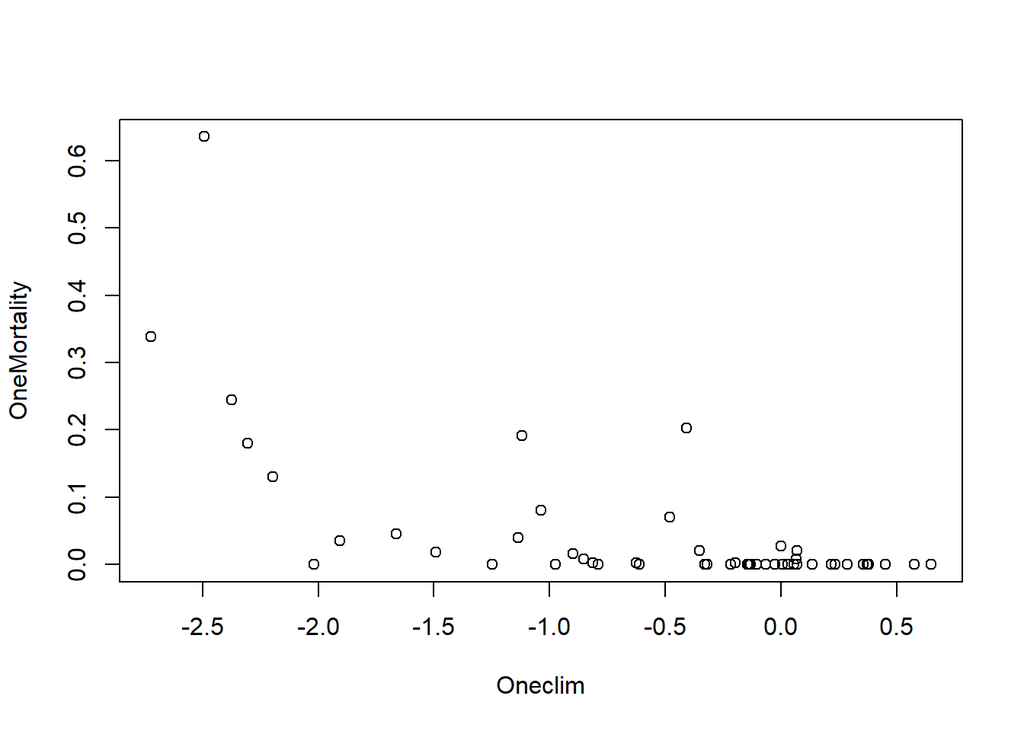

```r
Oneclim<-c(byyear2$HE_LL,byyear2$LE_LL,byyear2$HE_HL,byyear2$LE_HL)
OneMortality<-c(dfPerc$HE_LL_m,dfPerc$LE_LL_m,dfPerc$HE_HL_m,dfPerc$LE_HL_m)
plot(OneMortality~Oneclim)
```

#### Here is the figure used in the supplemental.

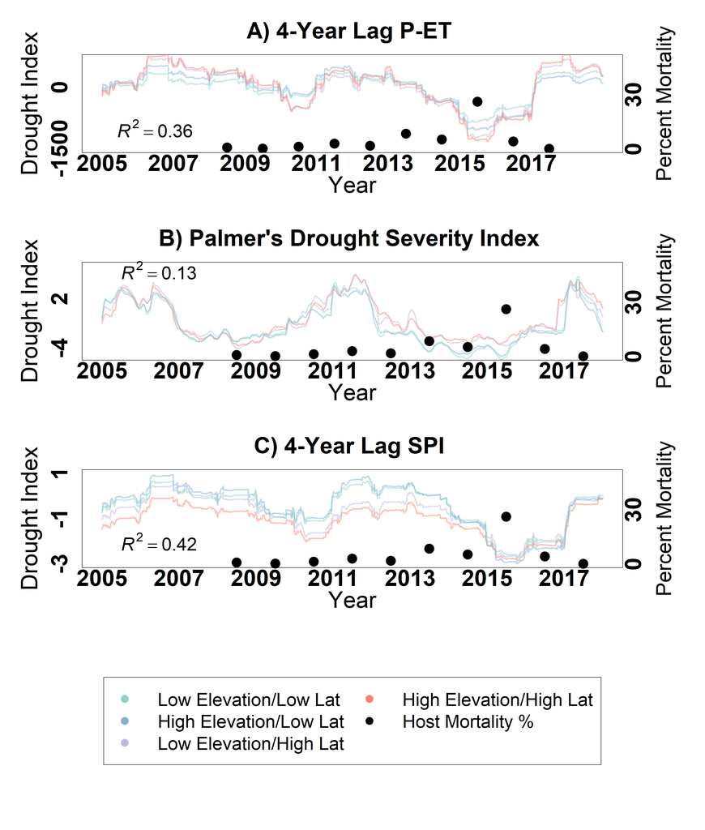

```r
#par(mar=c(15,7,10,33),xpd=F)
par(mfrow=c(4,1))

#### Figure1
Merged<-merge(Delta_df,Mortality,all.x=T,by="Dates")
Merged<-Merged[Merged$Dates>as.Date("2001-01-01"),]
#rint(Merged)
par(mar=c(10,15,10,15),xpd=F)

plot(as.Date(Merged[1460:nrow(Merged),1],origin = "1970-01-01"),roll_sum(Merged$Low_LowElDelta-mean(Merged$Low_LowElDelta),1460),col=adjustcolor(Pal_1[1],alpha.f=.5),ylim=c(-1510,700),
     cex.axis=2.8,cex.lab=2.5,type="l",lwd=3.0, ylab=NA,xlab=NA,yaxt="n",xaxt="n")
axis.Date(1,at=seq(as.Date(Merged$Dates)[1460], as.Date(Merged$Dates)[6569],by="year"),line=1.5,font.axis=2,
     font.lab=3.0,col=NA, cex.lab=4.0,cex.axis=5.0)
title(main="A) 4-Year Lag P-ET ", cex.main=5.0,line=3.0)
title(xlab="Year", cex.lab=5.0,line=6.5)
axis(side = 2,line=1.5,font.axis=2,font.lab=3.5,col=NA, cex.lab=5.0,cex.axis=5.0)
title(ylab="Drought Index", mgp=c(4,1,0),cex.lab=5.0,line=8.0)
#points(as.Date(Merged[,1]),cumsum(Delta_df$Low_MedElDelta-mean(Delta_df_sub$Low_MedElDelta))/19)
points((Merged[1460:nrow(Merged),1]),roll_sum(Merged$Low_MedElDelta-mean(Merged$Low_MedElDelta),1460),col=adjustcolor(Pal_1[5],alpha.f=.5),type="l",lwd=3.0)
points((Merged[1460:nrow(Merged),1]),roll_sum(Merged$High_LowElDelta-mean(Merged$High_LowElDelta),1460),col=adjustcolor(Pal_1[3],alpha.f=.5),type="l",lwd=3.0)
#points(as.Date(Merged[,1]),cumsum(Merged$High_MedElDelta-mean(Merged_sub$High_MedElDelta))/19,col=Pal_1[4])
points((Merged[1460:nrow(Merged),1]),roll_sum(Merged$High_HighElDelta-mean(Merged$High_HighElDelta),1460),col=adjustcolor(Pal_1[4],alpha.f=.5),type="l",lwd=3.0)
mylabel = bquote(italic(R)^2 == .(format( 0.3585, digits = 2)))
text(x = as.Date(Merged$Dates)[2000], y = -1000, labels = mylabel,cex=4.0)

par(new = T)
plot(as.Date(Merged$Dates)[1460:6569],Merged$AllPerc[1460:6569]*100,
                       pch=16, axes=F, ylim=c(0,50),xlab=NA,
                       ylab=NA, cex=5.0,)
  axis(side = 4,line=1.5,font.axis=2,font.lab=3.5,col=NA, cex.lab=5.0,cex.axis=5.0)
  mtext(side = 4, line = 8.0,cex=3.0, 'Percent Mortality')
par(xpd = T)


#### Figure 2

#Interporl
#png("Palmers.png", units="in", width=20.0, height=10.0, res=300)

plot(as.Date(Merged_PDSI$Dates),Merged_PDSI$HE_HL,
     col=adjustcolor(Pal_1[4],alpha.f=.5),ylim=c(-5,6),
    cex.axis=2.8,cex.lab=2.5,type="l",lwd=3.0,cex.main=4.0,
    ylab=NA,xlab=NA,yaxt="n",xaxt="n")
axis.Date(1,at=seq(as.Date(Merged$Dates)[1460], as.Date(Merged$Dates)[6205],by="year"),line=1.5,font.axis=2,
     font.lab=3.0,col=NA, cex.lab=4.0,cex.axis=5.0)
title(main="B) Palmer's Drought Severity Index ", cex.main=5.0,line=3.0)
title(xlab="Year", cex.lab=5.0,line=6.5)
axis(side = 2,line=1.5,font.axis=2,font.lab=3.5,col=NA, cex.lab=5.0,cex.axis=5.0)
title(ylab="Drought Index", mgp=c(4,1,0),cex.lab=5.0,line=8.0)

#points(as.Date(together[,1]),cumsum(Delta_df$Low_MedElDelta-mean(Delta_df_sub$Low_MedElDelta))/19)
points(as.Date(Merged_PDSI$Dates),Merged_PDSI$HE_LL,
       col=adjustcolor(Pal_1[5],alpha.f=.5),type="l",lwd=3.0)
points(as.Date(Merged_PDSI$Dates),Merged_PDSI$LE_HL,
       col=adjustcolor(Pal_1[3],alpha.f=.5),type="l",lwd=3.0)
#points(as.Date(together[,1]),cumsum(Delta_df$High_MedElDelta-mean(Delta_df_sub$High_MedElDelta))/19,col=Pal_1[4])
points(as.Date(Merged_PDSI$Dates),Merged_PDSI$LE_LL,
       col=adjustcolor(Pal_1[1],alpha.f=.5),type="l",lwd=3.0)
mylabel = bquote(italic(R)^2 == .(format( 0.1349, digits = 2)))
text(x = as.Date(Merged$Dates)[2000], y = 5.5, labels = mylabel,cex=4.0)
#abline(v=as.Date("2013-07-01"),lty=2.0)
#abline(v=as.Date("2014-07-01"),lty=3.0)
#abline(v=as.Date("2015-07-01"),lty=4.0)
#abline(v=as.Date("2016-07-01"),lty=5.0)
par(new = T)
plot(as.Date(Merged$Dates)[1460:6205],Merged$AllPerc[1460:6205]*100,
                       pch=16, axes=F, ylim=c(0,50),xlab=NA,
                       ylab=NA, cex=5.0,)
  axis(side = 4,line=1.5,font.axis=2,font.lab=3.5,col=NA, cex.lab=5.0,cex.axis=5.0)
  mtext(side = 4, line = 8.0,cex=3.0, 'Percent Mortality')
par(xpd = T)



### Number 3
PPT<-PPT_in[PPT_in$Dates %in% as.Date(Dates),]
PPT<-PPT[PPT$Dates>"2001-01-01",]
PPT<-PPT[order(PPT$Dates),]
Merged<-merge(PPT,Mortality,all.x=T,by="Dates")
#plot(as.Date(Dates)[1460:6206],(roll_sum(PPT$Low_LowElShape_OutPRCP,1460)-LE_LL_Mean)/LE_LL_SD)

plot(as.Date(Merged$Dates)[1460:6205],(roll_sum(Merged$High_HighElShape_OutPRCP,1460)-HE_HL_Mean)/HE_HL_SD,
     col=adjustcolor(Pal_1[4],alpha.f=.5),ylim=c(-3,1),#xlim=c(as.Date(PPT$Dates)[3993],as.Date(PPT$Dates)[6935])
       cex.axis=5.0,cex.lab=4.0,type="l",lwd=3.0,cex.main=7.0,ylab=NA,yaxt="n",xaxt="n",xlab=NA)
#axis(side = 1,as.Date(Merged$Dates)[1460:6205],
#     format(Merged$Dates[1460:6205], '%m-%d-%Y'),line=1.5,font.axis=2,
#     font.lab=3.0,col=NA, cex.lab=4.0,cex.axis=5.0)
axis.Date(1,at=seq(as.Date(Merged$Dates)[1460], as.Date(Merged$Dates)[6205],by="year"),line=1.5,font.axis=2,
     font.lab=3.0,col=NA, cex.lab=4.0,cex.axis=5.0)
title(main="C) 4-Year Lag SPI ", cex.main=5.0,line=3.0)
title(xlab="Year", cex.lab=5.0,line=6.5)
axis(side = 2,line=1.5,font.axis=2,font.lab=3.5,col=NA, cex.lab=5.0,cex.axis=5.0)
title(ylab="Drought Index", mgp=c(4,1,0),cex.lab=5.0,line=8.0)
points(as.Date(Merged$Dates)[1460:6205],(roll_sum(Merged$High_LowElShape_OutPRCP,1460)-LE_HL_Mean)/LE_HL_SD,
       col=adjustcolor(Pal_1[3],alpha.f=.5),type="l",lwd=3.0)
#points(as.Date(together[,1]),cumsum(Delta_df$Low_MedElDelta-mean(Delta_df_sub$Low_MedElDelta))/19)
points(as.Date(Merged$Dates)[1460:6205],(roll_sum(Merged$Low_LowElShape_OutPRCP,1460)-LE_LL_Mean)/LE_LL_SD,
       col=adjustcolor(Pal_1[1],alpha.f=.5),type="l",lwd=3.0)
points(as.Date(Merged$Dates)[1460:6205],(roll_sum(Merged$Low_MedElShape_OutPRCP,1460)-ME_LL_Mean)/ME_LL_SD,
       col=adjustcolor(Pal_1[5],alpha.f=.5),type="l",lwd=3.0)
mylabel = bquote(italic(R)^2 == .(format(0.4184, digits = 2)))
text(x = as.Date(Merged$Dates)[2000], y = -2, labels = mylabel,cex=4.0)

par(new = T)
plot(as.Date(Merged$Dates)[1460:6205],Merged$AllPerc[1460:6205]*100,
                       pch=16, axes=F, ylim=c(0,50),xlab=NA,
                       ylab=NA, cex=5.0,)
  axis(side = 4,line=1.5,font.axis=2,font.lab=3.5,col=NA, cex.lab=5.0,cex.axis=5.0)
  mtext(side = 4, line = 8.0,cex=3.0, 'Percent Mortality')
par(xpd = T)
#legend(as.Date("2020-09-01"),50,legend=c("Low Elevation/Low Lat","High Elevation/Low Lat",
 #                                             "Low Elevation/High Lat","High Elevation/High Lat",
#                                              "Host Mortality %"),
#         pch=c(16,16,16,16,16,NA),lty=c(NA,NA,NA,NA,NA,1),col=c(Pal_1[1],Pal_1[3],Pal_1[4],Pal_1[5],"black","black"),
#         cex=2.0)

plot(1, type = "n", axes=FALSE, xlab="", ylab="")
legend(x="top",inset=0,legend=c("Low Elevation/Low Lat","High Elevation/Low Lat",
                                              "Low Elevation/High Lat","High Elevation/High Lat",
                                              "Host Mortality %"),
         pch=c(16,16,16,16,16,NA),lty=c(NA,NA,NA,NA,NA,1),col=c(Pal_1[1],Pal_1[5],Pal_1[3],Pal_1[4],"black","black"),
         cex=4.0,bty=F,ncol=2)
```

### Current Drought Index

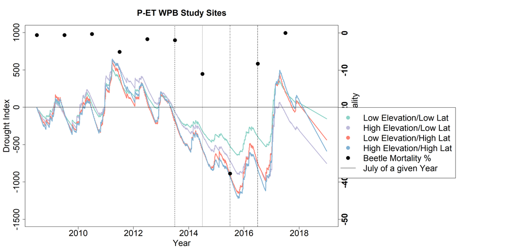

```r
Delta_Shorter<-Delta_df[Delta_df$Dates>"2008-07-01",]
Merged<-merge(Delta_Shorter,Mortality,all.x=T,by="Dates")

#jpeg(filename='C:/Users/zjrobbin/Documents/GitHub/IMAP_Python_Project/Written Documentation/Presentation/MPB_Drought.jpeg',quality=100)
together<-cbind(as.character(Delta_Shorter$Dates),Delta_Shorter$Low_MedElDelta)


par(mar=c(5,5,5,33),xpd=F)
plot(as.Date(together[,1]),cumsum(Delta_Shorter$Low_LowElDelta-mean(Delta_df_sub$Low_LowElDelta)),
     col=Pal_1[1],ylim=c(-1500,1000),
     ylab="Drought Index",xlab="Year",cex.axis=2.0,cex.lab=2.0,cex.main=2.0,type="l",lwd=3.0,
     main="P-ET WPB Study Sites")
#points(as.Date(together[,1]),cumsum(Delta_df$Low_MedElDelta-mean(Delta_df_sub$Low_MedElDelta))/19)
points(as.Date(together[,1]),cumsum(Delta_Shorter$Low_HighElDelta-mean(Delta_df_sub$Low_HighElDelta)),
       col=Pal_1[3],type="l",lwd=3.0)
points(as.Date(together[,1]),cumsum(Delta_Shorter$High_LowElDelta-mean(Delta_df_sub$High_LowElDelta)),
       col=Pal_1[4],type="l",lwd=3.0)
#points(as.Date(together[,1]),cumsum(Delta_df$High_MedElDelta-mean(Delta_df_sub$High_MedElDelta))/19,col=Pal_1[4])
points(as.Date(together[,1]),cumsum(Delta_Shorter$High_HighElDelta-mean(Delta_df_sub$High_HighElDelta)),
       col=Pal_1[5],type="l",lwd=3.0)
abline(h=0)

abline(v=as.Date("2013-07-01"),lty=2.0)
abline(v=as.Date("2014-07-01"),lty=3.0)
abline(v=as.Date("2015-07-01"),lty=4.0)
abline(v=as.Date("2016-07-01"),lty=5.0)
par(new = T)
with(d=Merged, plot(as.Date(Merged$Dates),-Merged$LargePerc*100,
                       pch=16, axes=F, ylim=c(-50,0.1),xlab=NA,
                       ylab=NA, cex=2.0))
  axis(side = 4,font.axis=2,font.lab=2,cex.lab=2.0,cex.axis=2.0)
  mtext(side = 4, line = 3,cex=2.0, '-Percent Mortality')
par(xpd = T)
legend(as.Date("2019-06-01"),-20,legend=c("Low Elevation/Low Lat","High Elevation/Low Lat",
                                              "Low Elevation/High Lat","High Elevation/High Lat",
                                              "Beetle Mortality %","July of a given Year"),
         pch=c(16,16,16,16,16,NA),lty=c(NA,NA,NA,NA,NA,1),col=c(Pal_1[1],Pal_1[3],Pal_1[4],Pal_1[5],"black","black"),
         cex=2.0)
```

```r
#?mtext()
```

#### Testing other year combinations

Here is an example with a Five Year Lag for P-ET, this can be used to change the rolling sum to test mulitple differnt lags.

```r
Delta_Shorter<-Delta_df[Delta_df$Dates>"2003-01-01",]
Merged<-merge(Delta_Shorter,Mortality,all.x=T,by="Dates")
Merged<-Merged[Merged$Dates>"2008-01-01",]
#jpeg(filename='C:/Users/zjrobbin/Documents/GitHub/IMAP_Python_Project/Written Documentation/Presentation/MPB_Drought.jpeg',quality=100)
together<-cbind(as.character(Delta_Shorter$Dates),Delta_Shorter$Low_MedElDelta)

nrow(together)
```

```
## [1] 5839
```

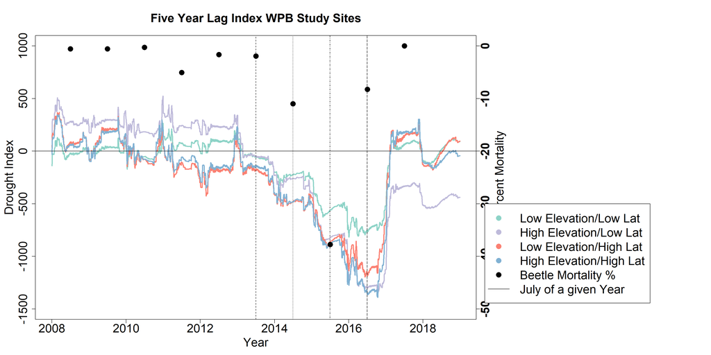

```r
par(mar=c(5,5,5,33),xpd=F)
plot(as.Date(together[1825:5839,1]),roll_sum((Delta_Shorter$Low_LowElDelta-mean(Delta_df_sub$Low_LowElDelta)),1825),
     col=Pal_1[1],ylim=c(-1500,1000),
     ylab="Drought Index",xlab="Year",cex.axis=2.0,cex.lab=2.0,cex.main=2.0,type="l",lwd=3.0,
     main="Five Year Lag Index WPB Study Sites")
#points(as.Date(together[,1]),cumsum(Delta_df$Low_MedElDelta-mean(Delta_df_sub$Low_MedElDelta))/19)
points(as.Date(together[1825:5839,1]),roll_sum((Delta_Shorter$Low_HighElDelta-mean(Delta_df_sub$Low_HighElDelta)),1825),
       col=Pal_1[3],type="l",lwd=3.0)
points(as.Date(together[1825:5839,1]),roll_sum((Delta_Shorter$High_LowElDelta-mean(Delta_df_sub$High_LowElDelta)),1825),
       col=Pal_1[4],type="l",lwd=3.0)
#points(as.Date(together[,1]),cumsum(Delta_df$High_MedElDelta-mean(Delta_df_sub$High_MedElDelta))/19,col=Pal_1[4])
points(as.Date(together[1825:5839,1]),roll_sum((Delta_Shorter$High_HighElDelta-mean(Delta_df_sub$High_HighElDelta)),1825),
       col=Pal_1[5],type="l",lwd=3.0)
abline(h=0)

abline(v=as.Date("2013-07-01"),lty=2.0)
abline(v=as.Date("2014-07-01"),lty=3.0)
abline(v=as.Date("2015-07-01"),lty=4.0)
abline(v=as.Date("2016-07-01"),lty=5.0)
par(new = T)
with(d=Merged, plot(as.Date(Merged$Dates),-Merged$LargePerc*100,
                       pch=16, axes=F, ylim=c(-50,0),xlab=NA,
                       ylab=NA, cex=2.0))
  axis(side = 4,font.axis=2,font.lab=2,cex.lab=2.0,cex.axis=2.0)
  mtext(side = 4, line = 3,cex=2.0, '-Percent Mortality')
par(xpd = T)
legend(as.Date("2019-09-01"),-30,legend=c("Low Elevation/Low Lat","High Elevation/Low Lat",
                                              "Low Elevation/High Lat","High Elevation/High Lat",
                                              "Beetle Mortality %","July of a given Year"),
         pch=c(16,16,16,16,16,NA),lty=c(NA,NA,NA,NA,NA,1),col=c(Pal_1[1],Pal_1[3],Pal_1[4],Pal_1[5],"black","black"),
         cex=2.0)
```